# US Bureau of Transportation Statistics Airline On-Time Performance - 2006

## by Marissa Mutare

# ON-TIME FLIGHT PERFORMANCE

## On Time Flights vs Delayed Flights

The overall flight performance mirrors the trend in the flight performance for arrivals and for departures, where there are more on time flights than delayed flights. 59.8% of departures are on time, while 54.4% of arrivals are on time. One possible factor for the disparity could be that arrivals are affected by departure delays as well as delays at the destination airport, where departures are only affected by delays at the origin airport.

The overall flight on time percentage is 64.6%.

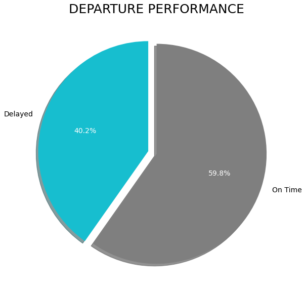

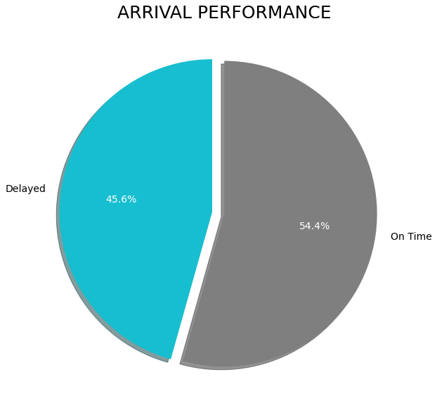

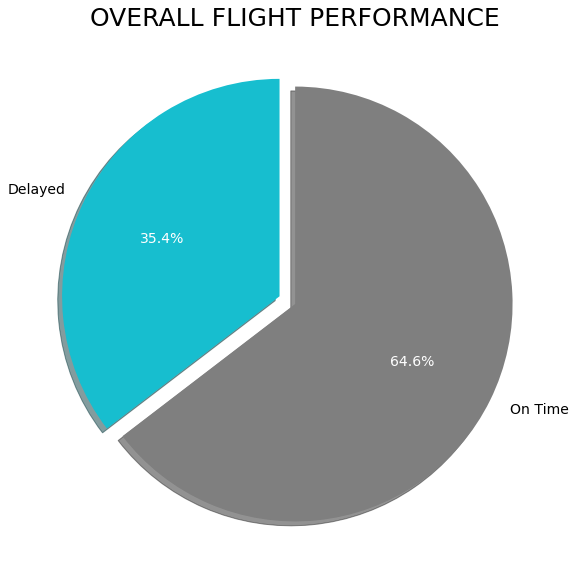

# FLIGHT FREQUENCY: DAYTIME VS NIGHTTIME

## Flight Departures: Daytime vs Nighttime

Most flights are scheduled to depart between 5 AM and 9 AM, and then peak again at 5 PM. The percentage of flights that are scheduled to depart between 6 AM and 6 PM is 78.4%.

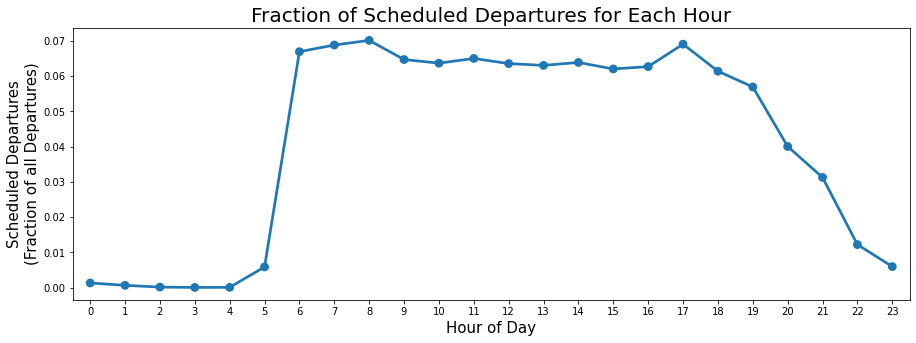

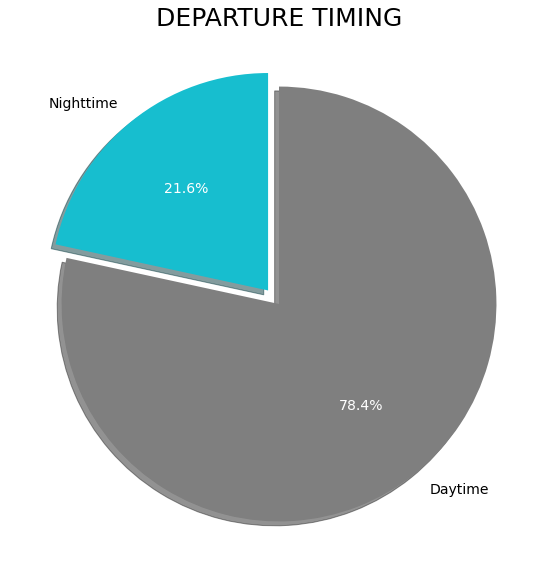

## Flight Arrivals: Daytime vs Nighttime

The highest peak of scheduled arrivals happens at 4 PM. The range between 10 AM and 9 PM is the highest in general. The percentage of flights that are scheduled to arrive between 6 AM and 6 PM is 66.1%.

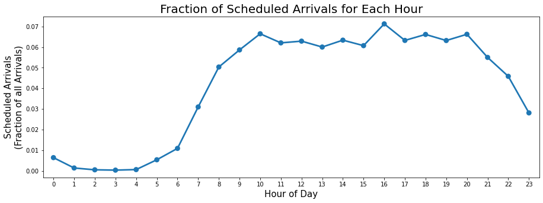

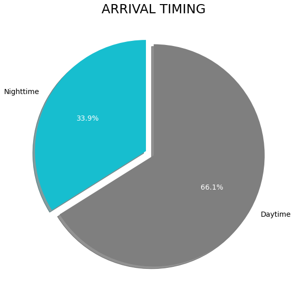

# FLIGHT ON-TIME PERFORMANCE: DAYTIME VS NIGHTTIME

## Flight Delays During Daytime vs Nighttime

Delayed flights surpass on time flights for departures scheduled between the hours of 5 PM and 9 PM. For arrivals, delays peak for flights scheduled to land between 6 PM and 1 AM. These numbers correspond, because flights that depart during the first range between 5 PM and 9 PM are likely to be landing during the second range of hours, 6 PM to 1 AM, depending on the distance and duration of the flight.

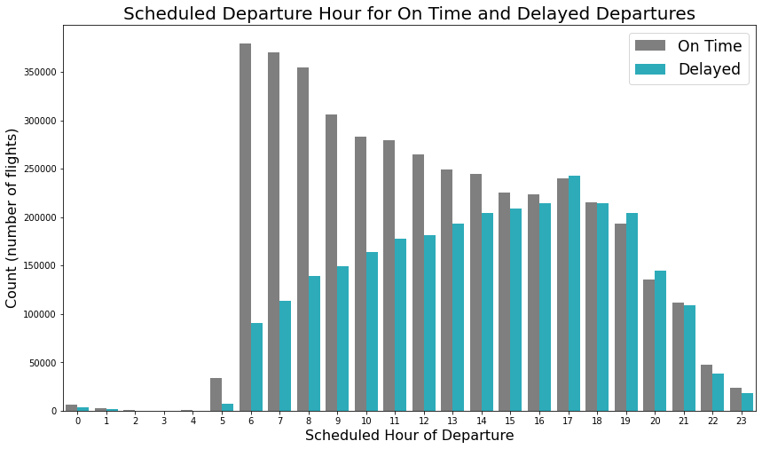

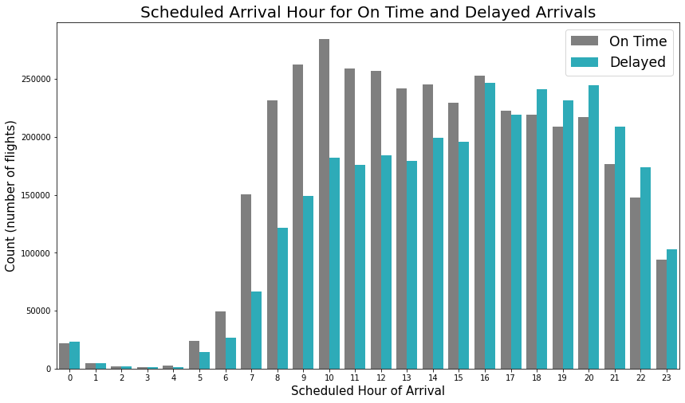